# EDA on Fraud Detection

## Objective

Main objective behind this notebook is to get an insight of the data and to explore different aspects of it.

## Content

- 1. Load libraries and Read data
     - 1.1. Load libraries
     - 1.2. Read data
- 1. Overview
     - 2.1. Head
     - 2.2. Target
     - 2.3. Missing values
- 1. Feature Engineering

## Attribute Information

1. step: Symbolizes a time unit in which one step equals one hour
2. type: Represents the type of online transactions
3. amount: The amount of the transaction
4. nameOrig: The customer that starts the transaction
5. oldbalanceOrg: The balance prior to the transaction
6. newbalanceOrig: The balance after the transaction is completed
7. nameDest: The recipient of the transaction
8. oldbalanceDest: The recipient's starting balance prior to the transaction
9. newbalanceDest: The recipient's new balance following the transaction
10. isFraud: Result of transaction, either fraud or not fraud

## 1. Load libraries and Read data

### 1.1. Load libraries

Loading the libraries

```python
import pandas as pd
import numpy as np
import matplotlib.pyplot as plt
import seaborn as sns
import warnings
from sklearn import preprocessing
from scipy.stats import skew,boxcox
from sklearn.feature_selection import SelectKBest
from sklearn.feature_selection import f_classif
from sklearn.model_selection import train_test_split
warnings.filterwarnings('ignore')
```

Setting the default values for plots

```python
plt.rc('axes', titlesize=18)
plt.rc('axes', labelsize=15)
plt.rc('xtick', labelsize=13)
plt.rc('ytick', labelsize=13)
plt.rc('figure', titlesize=35)
plt.rc('legend', fontsize=12)
```

### 1.2. Read data

Reading the data with pandas

```python
df=pd.read_csv('PS_20174392719_1491204439457_log.csv')
```

## 2. Overview

### 2.1. Head

Checking data head, info, summary statistics and null values

```python
df.head()
```

|  | step | type | amount | nameOrig | oldbalanceOrg | newbalanceOrig | nameDest | oldbalanceDest | newbalanceDest | isFraud | isFlaggedFraud |
| --- | --- | --- | --- | --- | --- | --- | --- | --- | --- | --- | --- |
| 0 | 1 | PAYMENT | 9839.64 | C1231006815 | 170136.0 | 160296.36 | M1979787155 | 0.0 | 0.0 | 0 | 0 |
| 1 | 1 | PAYMENT | 1864.28 | C1666544295 | 21249.0 | 19384.72 | M2044282225 | 0.0 | 0.0 | 0 | 0 |
| 2 | 1 | TRANSFER | 181.00 | C1305486145 | 181.0 | 0.00 | C553264065 | 0.0 | 0.0 | 1 | 0 |
| 3 | 1 | CASH_OUT | 181.00 | C840083671 | 181.0 | 0.00 | C38997010 | 21182.0 | 0.0 | 1 | 0 |
| 4 | 1 | PAYMENT | 11668.14 | C2048537720 | 41554.0 | 29885.86 | M1230701703 | 0.0 | 0.0 | 0 | 0 |

```python
df.info()
```

```
<class 'pandas.core.frame.DataFrame'>
RangeIndex: 6362620 entries, 0 to 6362619
Data columns (total 11 columns):
 #   Column          Dtype
---  ------          -----
 0   step            int64
 1   type            object
 2   amount          float64
 3   nameOrig        object
 4   oldbalanceOrg   float64
 5   newbalanceOrig  float64
 6   nameDest        object
 7   oldbalanceDest  float64
 8   newbalanceDest  float64
 9   isFraud         int64
 10  isFlaggedFraud  int64
dtypes: float64(5), int64(3), object(3)
memory usage: 534.0+ MB
```

```python
df.describe()
```

|  | step | amount | oldbalanceOrg | newbalanceOrig | oldbalanceDest | newbalanceDest | isFraud | isFlaggedFraud |
| --- | --- | --- | --- | --- | --- | --- | --- | --- |
| count | 6.362620e+06 | 6.362620e+06 | 6.362620e+06 | 6.362620e+06 | 6.362620e+06 | 6.362620e+06 | 6.362620e+06 | 6.362620e+06 |
| mean | 2.433972e+02 | 1.798619e+05 | 8.338831e+05 | 8.551137e+05 | 1.100702e+06 | 1.224996e+06 | 1.290820e-03 | 2.514687e-06 |
| std | 1.423320e+02 | 6.038582e+05 | 2.888243e+06 | 2.924049e+06 | 3.399180e+06 | 3.674129e+06 | 3.590480e-02 | 1.585775e-03 |
| min | 1.000000e+00 | 0.000000e+00 | 0.000000e+00 | 0.000000e+00 | 0.000000e+00 | 0.000000e+00 | 0.000000e+00 | 0.000000e+00 |
| 25% | 1.560000e+02 | 1.338957e+04 | 0.000000e+00 | 0.000000e+00 | 0.000000e+00 | 0.000000e+00 | 0.000000e+00 | 0.000000e+00 |
| 50% | 2.390000e+02 | 7.487194e+04 | 1.420800e+04 | 0.000000e+00 | 1.327057e+05 | 2.146614e+05 | 0.000000e+00 | 0.000000e+00 |
| 75% | 3.350000e+02 | 2.087215e+05 | 1.073152e+05 | 1.442584e+05 | 9.430367e+05 | 1.111909e+06 | 0.000000e+00 | 0.000000e+00 |
| max | 7.430000e+02 | 9.244552e+07 | 5.958504e+07 | 4.958504e+07 | 3.560159e+08 | 3.561793e+08 | 1.000000e+00 | 1.000000e+00 |

```python
df.isnull().any()
```

```
step              False
type              False
amount            False
nameOrig          False
oldbalanceOrg     False
newbalanceOrig    False
nameDest          False
oldbalanceDest    False
newbalanceDest    False
isFraud           False
isFlaggedFraud    False
dtype: bool
```

The dataset consists of several predictor variables and one target variable, isFraud. The dataset consists of 6362620 entries with non-null values.

### 2.2. Target

How many fraud transactions are present in the data?

What is the target distribution?

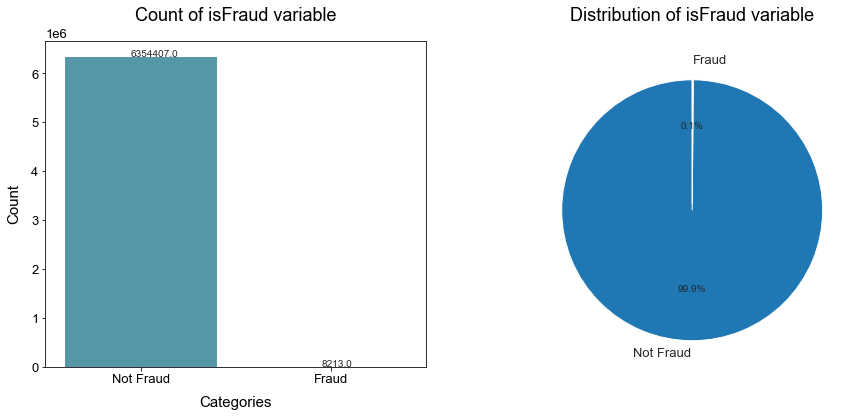

```python
fig,ax=plt.subplots(1,2,figsize=(15,6))
sns.set_style('ticks')
sns.set_palette('Spectral_r')
sns.barplot(x=['Not Fraud','Fraud'], y=df['isFraud'].value_counts().values,ax=ax[0])
ax[0].set_title('Count of isFraud variable',pad=20)
ax[0].set_ylabel('Count',labelpad=10)
ax[0].set_xlabel('Categories',labelpad=10)
plt.pie(df['isFraud'].value_counts(),explode=[0.05,0.0],labels=['Not Fraud','Fraud'],startangle=90,autopct='%1.1f%%')
plt.title('Distribution of isFraud variable',pad=20)
for p in ax[0].patches:
    ax[0].annotate(str(p.get_height()), (p.get_x(), p.get_height()),xytext=(p.get_x()+0.35,p.get_height()+5))
plt.show()
```

From the above graph we can say that only a handfull of the transactions are Fraud with parcentage of 0.1%.

```python
print(df['isFraud'].value_counts())
```

```
0    6354407
1       8213
Name: isFraud, dtype: int64
```

6354407 transactions are not fraud while other 8213 are fraud.

### 2.3. Missing values

Some features contain 0 in the data. It doesn't make sense here beacuse there is no change in the old balance or the new balance in some transactions. By further looking into the data we found that it is because there are a number of factors involved in the data to correctly access the reason for the change in balance, one of them being the type feature.

Let's get some more insight's about the features with box plot

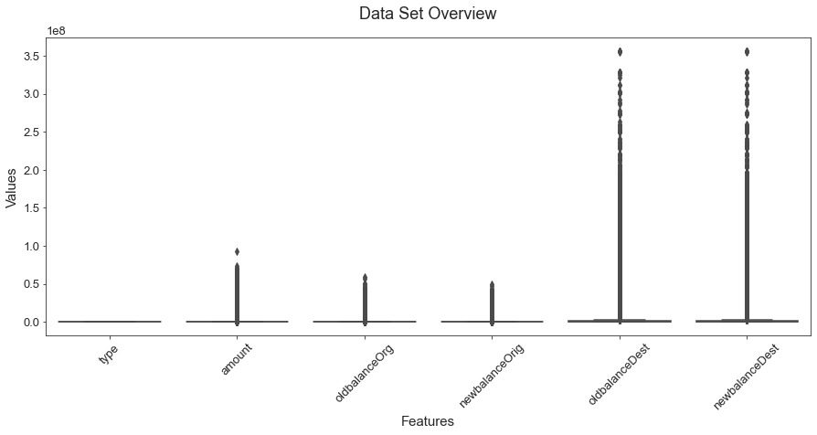

```python
df_new = df.drop(['step','nameOrig','nameDest','isFlaggedFraud'],axis=1)
df_new["type"] = df["type"].map({"CASH_OUT": 1, "PAYMENT": 2, "CASH_IN": 3, "TRANSFER": 4,"DEBIT": 5})
df_melted=pd.melt(frame=df_new,id_vars='isFraud',var_name='Features',value_name='Values')
fig,ax=plt.subplots(figsize=(15,6))
ax=sns.boxplot(x='Features',y='Values',data=df_melted)
ax.set_xticklabels(ax.get_xticklabels(),rotation=45)
plt.title('Data Set Overview',pad=20)
plt.show()
```

From above plot we can see that there are outliers in the data which is totally understandable as we are dealing with online transactions data.

```python
df_dang=df_new[df_new['isFraud']!=0]
df_safe=df_new[df_new['isFraud']==0]

def dist_plot(feature,bins):
    plt.figure(figsize=(15,6))
    sns.set_palette('Set1')
    ax=sns.distplot(df_dang[feature].dropna(),hist=True,kde=True,bins=bins,label='Fraud')
    ax=sns.distplot(df_safe[feature].dropna(),hist=True,kde=True,bins=bins,label='Not Fraud')
    ax.set_xlabel(None)
    ax.legend()
    plt.title(feature,pad=20)
    plt.show()
```

## 3. Feature Engineering

- **Type** : Represents the type of online transactions

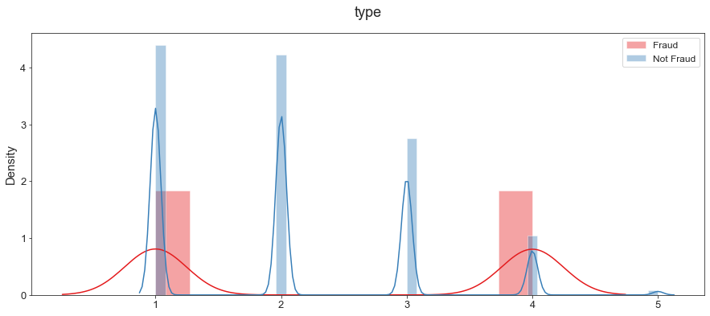

```python
dist_plot('type',None)
```

We can see from the above data that only two type of transactions are classified as fraud so we will drop the remaining types to generalize the data and we will only keep Cash_out and Transfer type.

```python
df = df.loc[(df['type'].isin(['TRANSFER', 'CASH_OUT'])),:]
```

The Type feature in our data is catigorical so we will map it to convert it to numerical data.

```python
df["type"] = df["type"].map({"CASH_OUT": 1,"TRANSFER": 2})
```

Let's take a look at the target distribution once again.

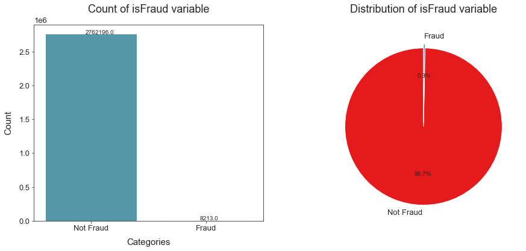

```python
fig,ax=plt.subplots(1,2,figsize=(15,6))
sns.set_style('ticks')
sns.set_palette('Spectral_r')
sns.barplot(x=['Not Fraud','Fraud'], y=df['isFraud'].value_counts().values,ax=ax[0])
ax[0].set_title('Count of isFraud variable',pad=20)
ax[0].set_ylabel('Count',labelpad=10)
ax[0].set_xlabel('Categories',labelpad=10)
plt.pie(df['isFraud'].value_counts(),explode=[0.05,0.0],labels=['Not Fraud','Fraud'],startangle=90,autopct='%1.1f%%')
plt.title('Distribution of isFraud variable',pad=20)
for p in ax[0].patches:
    ax[0].annotate(str(p.get_height()), (p.get_x(), p.get_height()),xytext=(p.get_x()+0.35,p.get_height()+5))
plt.show()
```

Let's explore more feature to get more insight from dataset

```python
def feature_analysis(x_feat,y_feat):
    sns.set_style('darkgrid')
    sns.set_palette('Set1')
    x=sns.relplot(x=x_feat,y=y_feat,hue='isFraud',style='isFraud',data=df,kind='scatter',height=5,aspect=2.5)
    plt.title(x_feat+' vs '+y_feat,pad=20)
    plt.show()
```

First let's visualize a correlation matrix. A correlation matrix is a table showing correlation coefficients between sets of variables. Each random variable in the table is correlated with each of the other values in the table. This allows you to see which pairs have the highest correlation.

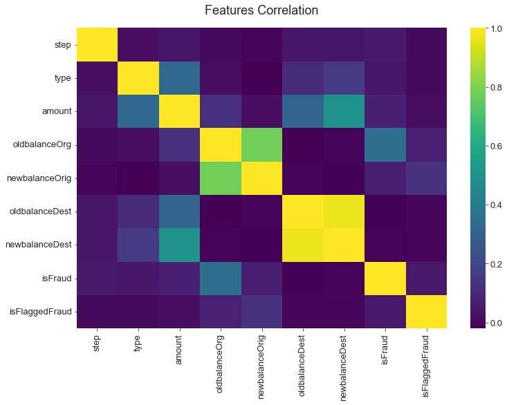

```python
plt.figure(figsize=(12,8))
sns.heatmap(df.corr(),cmap='viridis')
plt.title('Features Correlation',pad=20)
```

From the above correlation graph we can see that highly correlated features are newbalanceOrig vs oldbalanceOrg, newbalanceDest vs oldbalanceDest and newbalanceDest vs amount.

Now we will perform ANOVA F statistics test on our data. Since F statistics is greater than 3.95, so the features are significant.

```python
def select_features(X_train, y_train, X_test):
    # configure to select all features
    fs = SelectKBest(score_func=f_classif, k='all')
    # learn relationship from training data
    fs.fit(X_train, y_train)
    # transform train input data
    X_train_fs = fs.transform(X_train)
    # transform test input data
    X_test_fs = fs.transform(X_test)
    return X_train_fs, X_test_fs, fs
```

```python
y = df['isFraud']
X = df.drop(['nameOrig','nameDest','isFraud'], axis = 1)
X_train, X_test, y_train, y_test = train_test_split(X, y, test_size = 0.33, random_state = 0)
```

```
Feature 0: 4283.494629
Feature 1: 3296.902275
Feature 2: 9422.045628
Feature 3: 250415.003658
Feature 4: 8450.630943
Feature 5: 385.153554
Feature 6: 133.244100
Feature 7: 4045.919488
```

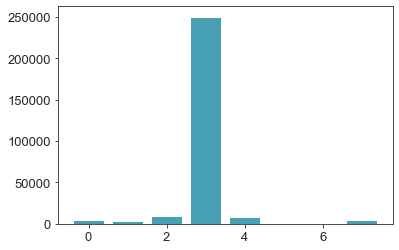

```python
# feature selection
X_train_fs, X_test_fs, fs = select_features(X_train, y_train, X_test)
# what are scores for the features
for i in range(len(fs.scores_)):
    print('Feature %d: %f' % (i, fs.scores_[i]))
# plot the scores
plt.bar([i for i in range(len(fs.scores_))], fs.scores_)
plt.show()
```

```python
X.head()
```

|  | step | type | amount | oldbalanceOrg | newbalanceOrig | oldbalanceDest | newbalanceDest | isFlaggedFraud |
| --- | --- | --- | --- | --- | --- | --- | --- | --- |
| 2 | 1 | 2 | 181.00 | 181.0 | 0.0 | 0.0 | 0.00 | 0 |
| 3 | 1 | 1 | 181.00 | 181.0 | 0.0 | 21182.0 | 0.00 | 0 |
| 15 | 1 | 1 | 229133.94 | 15325.0 | 0.0 | 5083.0 | 51513.44 | 0 |
| 19 | 1 | 2 | 215310.30 | 705.0 | 0.0 | 22425.0 | 0.00 | 0 |
| 24 | 1 | 2 | 311685.89 | 10835.0 | 0.0 | 6267.0 | 2719172.89 | 0 |

Now we will try to scale the data.

```python
def skewing(feature_new,feature):
    df[feature_new] = preprocessing.scale(boxcox(df[feature]+1)[0])
    figure = plt.figure(figsize=(15, 6))
    plt.hist(df[feature] ,facecolor='blue',alpha=0.75)
    plt.title(feature +' Before Skewing',pad=20)
    figure = plt.figure(figsize=(15, 6))
    plt.hist(df[feature_new], facecolor = 'red', alpha=0.5)
    plt.title(feature +' After Skewing',pad=20)
    plt.show()
```

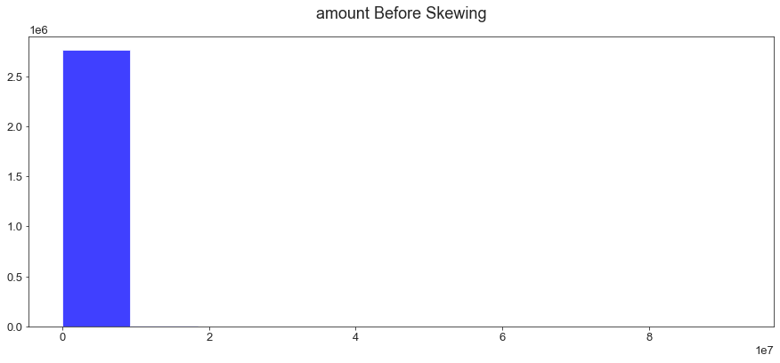

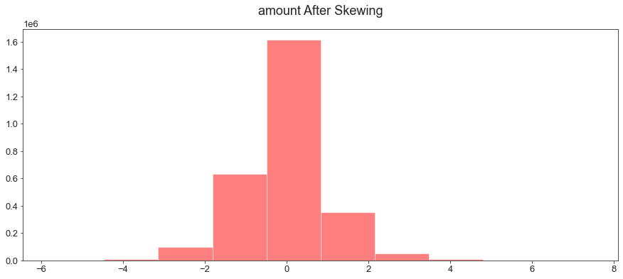

```python
skewing('amount_new','amount')
```

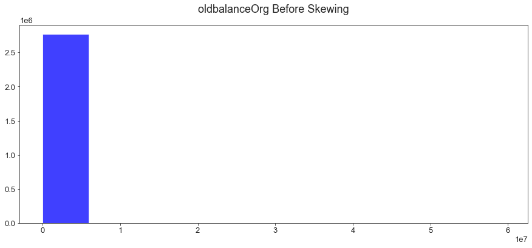

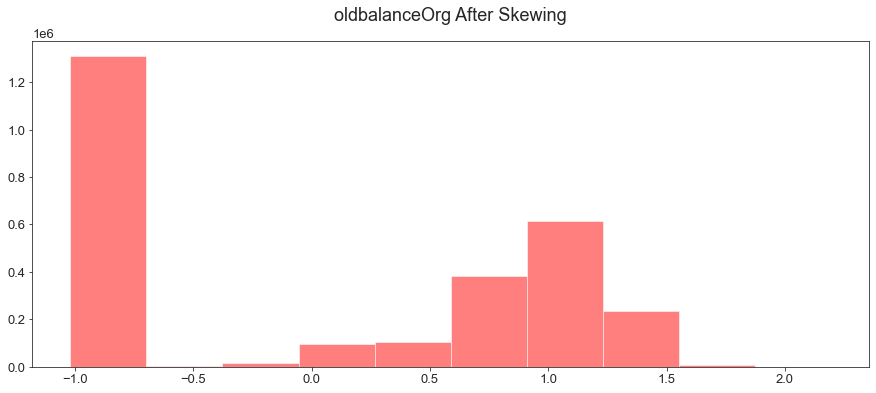

```python
skewing('oldbalanceOrg_new','oldbalanceOrg')
```

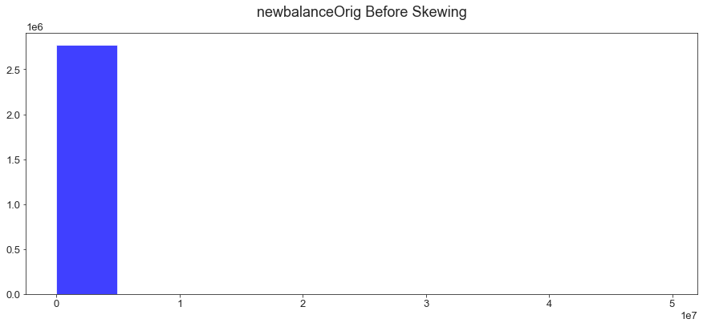

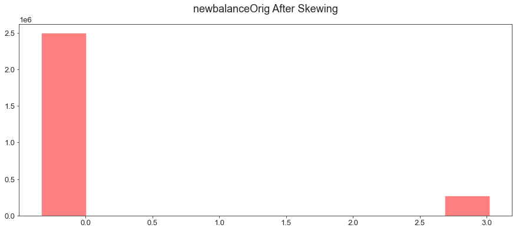

```python
skewing('newbalanceOrig_new','newbalanceOrig')
```

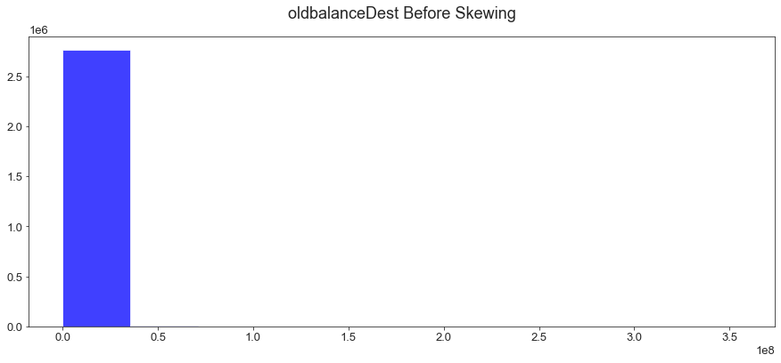

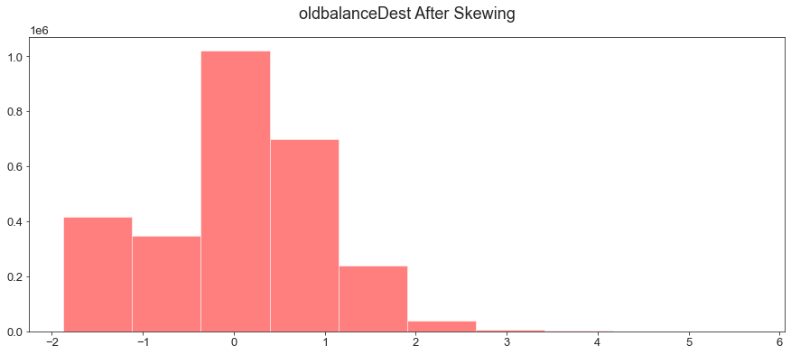

```python
skewing('oldbalanceDest_new','oldbalanceDest')
```

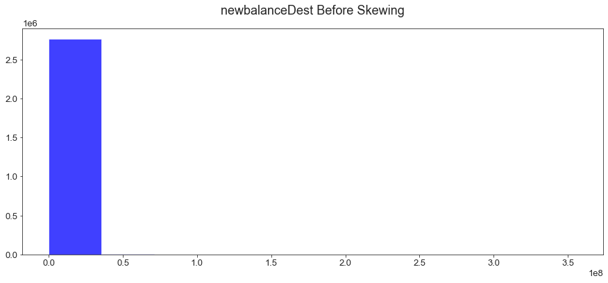

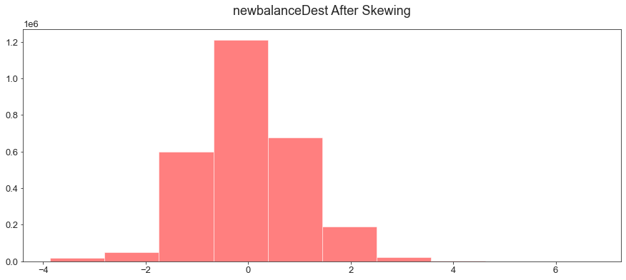

```python
skewing('newbalanceDest_new','newbalanceDest')
```

Now we will drop the uninterested and unscaled features from the dataset.

```python
df = df.drop(['oldbalanceOrg', 'newbalanceOrig', 'oldbalanceDest', 'newbalanceDest', 'amount', 'type','step','nameOrig','nameDest','oldbalanceDest','newbalanceDest','isFlaggedFraud'],axis=1)
```

Let's save this data set to use it later for our model.

```python
df.to_csv('new_data.csv', index=False)
```

All the insight that we gathered by analyzing the different features will be very usefull for our model.